# PML Prediction Assignment

Denver Durham

12/31/2016

# Introduction

Using devices such as Jawbone Up, Nike FuelBand, and Fitbit it is now possible to collect a large amount of data about personal activity relatively inexpensively. These type of devices are part of the quantified self movement – a group of enthusiasts who take measurements about themselves regularly to improve their health, to find patterns in their behavior, or because they are tech geeks. One thing that people regularly do is quantify how much of a particular activity they do, but they rarely quantify how well they do it.

The goal of this project will be to use data from accelerometers on the belt, forearm, arm, and dumbell of 6 participants to predict the method of movement. They were asked to perform barbell lifts correctly and incorrectly in 5 different ways. More information is available from the website here: http://groupware.les.inf.puc-rio.br/har (see the section on the Weight Lifting Exercise Dataset).

## Data

The training data for this project are available here: [link](https://d396qusza40orc.cloudfront.net/predmachlearn/pml-training.csv)

The test data are available here: [link](https://d396qusza40orc.cloudfront.net/predmachlearn/pml-testing.csv)

# Setup

We will begin by loading the necessary packages and importing the data. We will primarily depend on the Caret package, as well as rpart, gbm, and randomForest.

```r
library(caret)
```

```r
library(pgmm)
library(rpart)
library(rpart.plot)
library(gbm)
library(randomForest)
## Importing the Data
pml_train <- read.csv('pml-training.csv', header=T, na.strings=c("NA","#DIV/0!",""),
                      stringsAsFactors = F)
pml_test <- read.csv('pml-testing.csv', header=T, na.strings=c("NA","#DIV/0!",""),
                     stringsAsFactors = F)
```

# Observe the Data

Initial observation of the data reveals that there are a number of columns irrelevant to our prediction models as well as a large number of NA’s in any unused columns of gyroscopic readings.

# Clean and Partition the Data

```r
## Partitioning the Data
pml_train$classe <- as.factor(pml_train$classe)
set.seed(33833)
inTrain <- createDataPartition(pml_train$classe, p=0.6, list=FALSE)
training <- pml_train[inTrain,]
testing <- pml_train[-inTrain,]

## Cleaning the Data
nzv <- nearZeroVar(training)
training <- training[, -nzv]
testing <- testing[, -nzv]

# remove variables that are high frequency NA
mostlyNA <- sapply(training, function(x) mean(is.na(x))) > 0.95
training <- training[, mostlyNA==F]
testing <- testing[, mostlyNA==F]

# remove variables that don't make sense for prediction model
training <- training[, -(1:5)]
testing <- testing[, -(1:5)]
```

# Modeling and Predicting the Data

## Building a Random Forest

```r
## Building Random Forest
set.seed(3833)
model_rf <- train(classe~ ., data = training, method="rf")
pred_rf <- predict(model_rf, testing)
confusionMatrix(pred_rf, testing$classe)
```

```
## Confusion Matrix and Statistics
##
##           Reference
## Prediction    A    B    C    D    E
##          A 2231    1    0    0    0
##          B    1 1517    0    0    0
##          C    0    0 1368    6    0
##          D    0    0    0 1280    8
##          E    0    0    0    0 1434
##
## Overall Statistics
##
##                Accuracy : 0.998
##                  95% CI : (0.9967, 0.9988)
##     No Information Rate : 0.2845
##     P-Value [Acc > NIR] : < 2.2e-16
##
##                   Kappa : 0.9974
##  Mcnemar's Test P-Value : NA
##
## Statistics by Class:
##
##                      Class: A Class: B Class: C Class: D Class: E
## Sensitivity            0.9996   0.9993   1.0000   0.9953   0.9945
## Specificity            0.9998   0.9998   0.9991   0.9988   1.0000
## Pos Pred Value         0.9996   0.9993   0.9956   0.9938   1.0000
## Neg Pred Value         0.9998   0.9998   1.0000   0.9991   0.9988
## Prevalence             0.2845   0.1935   0.1744   0.1639   0.1838
## Detection Rate         0.2843   0.1933   0.1744   0.1631   0.1828
## Detection Prevalence   0.2845   0.1935   0.1751   0.1642   0.1828
## Balanced Accuracy      0.9997   0.9996   0.9995   0.9971   0.9972
```

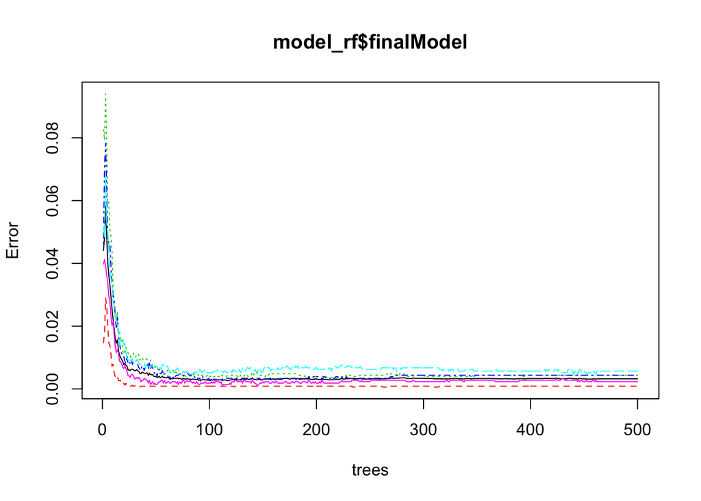

```r
plot(model_rf$finalModel)
```

Random Forest yields an exceptional accuracy rate of prediction at 99.8%. We will continue with the addtional models however, to be thorough in our search for the best prediction.

## Building a Boosting Model

```r
## Building Boosting Model
set.seed(3833)
model_gbm <- train(classe~ ., data= training, method="gbm")
pred_gbm <- predict(model_gbm, testing)
confusionMatrix(pred_gbm, testing$classe)
```

```
## Confusion Matrix and Statistics
##
##           Reference
## Prediction    A    B    C    D    E
##          A 2222   12    0    1    0
##          B    8 1488   10    7    5
##          C    0   15 1356   10    3
##          D    0    3    2 1268   18
##          E    2    0    0    0 1416
##
## Overall Statistics
##
##                Accuracy : 0.9878
##                  95% CI : (0.9851, 0.9901)
##     No Information Rate : 0.2845
##     P-Value [Acc > NIR] : < 2.2e-16
##
##                   Kappa : 0.9845
##  Mcnemar's Test P-Value : NA
##
## Statistics by Class:
##
##                      Class: A Class: B Class: C Class: D Class: E
## Sensitivity            0.9955   0.9802   0.9912   0.9860   0.9820
## Specificity            0.9977   0.9953   0.9957   0.9965   0.9997
## Pos Pred Value         0.9942   0.9802   0.9798   0.9822   0.9986
## Neg Pred Value         0.9982   0.9953   0.9981   0.9973   0.9960
## Prevalence             0.2845   0.1935   0.1744   0.1639   0.1838
## Detection Rate         0.2832   0.1897   0.1728   0.1616   0.1805
## Detection Prevalence   0.2849   0.1935   0.1764   0.1645   0.1807
## Balanced Accuracy      0.9966   0.9877   0.9935   0.9912   0.9908
```

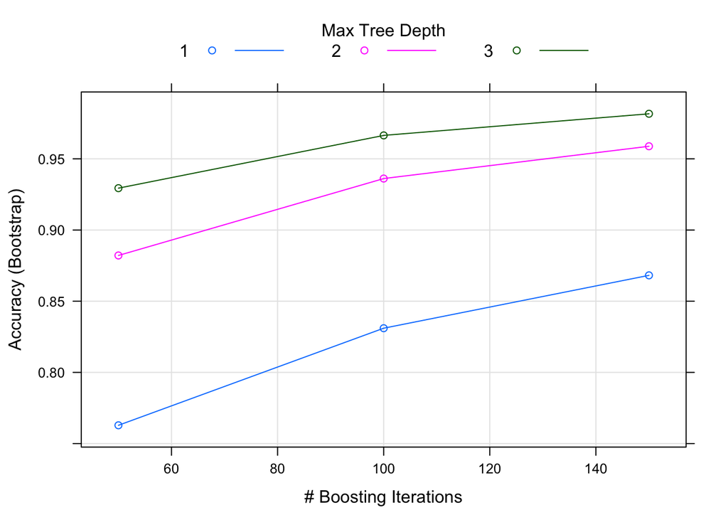

```r
plot(model_gbm)
```

Boosting also provided an excellent accuracy of 98.7%. The graph illustrates the increase in accuracy with bootstrapping and branch iterations.

Last we will consider an Rpart model.

## Building an Rpart Model

```r
## Building Rpart
set.seed(3833)
model_rpart <- train(classe~., data = training, method="rpart")
pred_rpart <- predict(model_rpart, testing)
confusionMatrix(pred_rpart, testing$classe)
```

```
## Confusion Matrix and Statistics
##
##           Reference
## Prediction    A    B    C    D    E
##          A 2003  581  633  541  142
##          B   35  542   38  246  105
##          C  189  395  697  440  317
##          D    0    0    0    0    0
##          E    5    0    0   59  878
##
## Overall Statistics
##
##                Accuracy : 0.5251
##                  95% CI : (0.514, 0.5362)
##     No Information Rate : 0.2845
##     P-Value [Acc > NIR] : < 2.2e-16
##
##                   Kappa : 0.3812
##  Mcnemar's Test P-Value : < 2.2e-16
##
## Statistics by Class:
##
##                      Class: A Class: B Class: C Class: D Class: E
## Sensitivity            0.8974  0.35705  0.50950   0.0000   0.6089
## Specificity            0.6621  0.93300  0.79299   1.0000   0.9900
## Pos Pred Value         0.5136  0.56108  0.34200      NaN   0.9321
## Neg Pred Value         0.9420  0.85814  0.88447   0.8361   0.9183
## Prevalence             0.2845  0.19347  0.17436   0.1639   0.1838
## Detection Rate         0.2553  0.06908  0.08884   0.0000   0.1119
## Detection Prevalence   0.4971  0.12312  0.25975   0.0000   0.1201
## Balanced Accuracy      0.7797  0.64502  0.65125   0.5000   0.7994
```

Rpart accuracy is much lower, barely over 52.5%, so we will eliminate this as a possible model for our dataset.

## Building a Combined Model

Given the very high accuracy with both Random Forest and GBM, we can build a combined model to see if the accuracy will go any higher. This really is just an experimental step however, considering that the RF yielded an accuracy of 99.8%. We also risk overfitting the training data, but we’re curious how much it would affect the accuracy!

```r
# Combined Model utilizing Random Forest
set.seed(3833)
predDF <- data.frame(pred_rf, pred_gbm, classe = testing$classe)
combModFit <- train(classe ~ ., method = "rf", data = predDF)
combPred <- predict(combModFit, predDF)
confusionMatrix(combPred, testing$classe)
```

```
## Confusion Matrix and Statistics
##
##           Reference
## Prediction    A    B    C    D    E
##          A 2231    1    0    0    0
##          B    1 1517    0    0    0
##          C    0    0 1366    3    0
##          D    0    0    2 1283    8
##          E    0    0    0    0 1434
##
## Overall Statistics
##
##                Accuracy : 0.9981
##                  95% CI : (0.9968, 0.9989)
##     No Information Rate : 0.2845
##     P-Value [Acc > NIR] : < 2.2e-16
##
##                   Kappa : 0.9976
##  Mcnemar's Test P-Value : NA
##
## Statistics by Class:
##
##                      Class: A Class: B Class: C Class: D Class: E
## Sensitivity            0.9996   0.9993   0.9985   0.9977   0.9945
## Specificity            0.9998   0.9998   0.9995   0.9985   1.0000
## Pos Pred Value         0.9996   0.9993   0.9978   0.9923   1.0000
## Neg Pred Value         0.9998   0.9998   0.9997   0.9995   0.9988
## Prevalence             0.2845   0.1935   0.1744   0.1639   0.1838
## Detection Rate         0.2843   0.1933   0.1741   0.1635   0.1828
## Detection Prevalence   0.2845   0.1935   0.1745   0.1648   0.1828
## Balanced Accuracy      0.9997   0.9996   0.9990   0.9981   0.9972
```

# Predicting the Test data

## Cleaning the Test data

```r
pml_test <- pml_test[, -nzv]
pml_test <- pml_test[, mostlyNA==F]
pml_test <- pml_test[, -(1:5)]
```

## Random Forest Prediction

```r
predictionRF <- predict(model_rf, pml_test)
predictionRF
```

```
##  [1] B A B A A E D B A A B C B A E E A B B B
## Levels: A B C D E
```